# Certificat Data Scientist Document Data Pipeline

29 novembre 2023

## Introduction

Un **pipeline de traitement de données** (*data pipeline*) fait le lien entre des **producteurs de données** (*data producers*) et des **consommateurs de données** (*data consumers*).

**Objectif :** présenter un exemple simple de pipeline de traitement de données orienté document.

- Récupération de données depuis des sites internet
- Filtrage et mise en forme des données
- Stockage dans une base de données
- Exploitation et valorisation des données

## JSON, un format document

## Notion de document

Pas de réelle définition mais quelques propriétés :

- un **document** contient des données encodées dans un certain **format**,
- le **contenu** d’un document est un ensemble de paires **clé/valeur**,
- absence de **schéma** fixe a priori,
- un document peut contenir d’autres documents.

Exemples :

- format texte : **JSON**, XML, YML, …
- format binaire : BSON, PDF, …

## Format JSON

JSON (*JavaScript Object Notation*) est un format document léger et très utilisé qui se veut lisible autant par des humains que par des machines.

La syntaxe est simple et un document se présente comme un **objet** unique délimité par des accolades `{}`. Les paires clé/valeur sont séparées par des virgules.

```json
{
  "clé1": valeur1,
  "clé2": valeur2,
  ...
}
```

Les clés sont des chaînes de caractères délimitées par des guillemets `""` et tous les caractères blancs (espace, tabulation et retour à la ligne) sont ignorés.

Les valeurs peuvent avoir des types différents.

## Format JSON - Types simples

- **chaîne de caractères** : séquence de caractères Unicode délimitée par des guillemets `""`,
- **nombre** : flottants double précision (notation entière, décimale ou scientifique),
- **booléen** : `true` et `false` (en minuscules),
- **null** : valeur vide.

```json
{
  "nom": "Gandalf",
  "taille": 1.68,
  "anneaux": 1,
  "magicien": true,
  "résidence": null
}
```

## Format JSON - Types structurés

- **tableau** : liste **ordonnée** de valeurs entre crochets `[]` (similaire aux vecteurs de **R**),
- **objet** : liste **non ordonnée** de paires clé/valeur entre accolades `{}` (similaire aux listes de **R**).

```json
{
  "nom": "Gandalf",
  "stuff": ["Glamdring", "Bâton de magicien", "Narya"],
  "alias": {
    "sindarin": "Mithrandir",
    "quenya": "Olórin"
  }
}
```

## Format JSON - Imbrication

Pour un type structuré, les valeurs peuvent être de n’importe quel type y compris un autre type structuré.

```json
{
  "nom": "Sacquet", "prénom": "Frodon",
  "amis": [
    {
      "nom": "Gamegie", "prénom": "Samsagace"
    },
    {
      "nom": "Brandebouc", "prénom": "Meriadoc"
    },
    {
      "nom": "Touque", "prénom": "Peregrin"
    }
  ]
}
```

## Package `jsonlite`

Le package [`jsonlite`](https://cran.r-project.org/web/packages/jsonlite/index.html) permet de manipuler simplement des données document au format JSON avec **R**. L’argument `pretty = TRUE` indente l’affichage de l’objet `json` avec des espaces.

```r
library(jsonlite)
json <- toJSON(list(nom = "Gandalf", taille = 1.68, residence = NA), pretty = TRUE)
class(json); typeof(json); print(json)
```

```
## [1] "json"
```

```
## [1] "character"
```

```
## {
##   "nom": ["Gandalf"],
##   "taille": [1.68],
##   "residence": [null]
## }
```

## Package `jsonlite` - Import/Export

La fonction `toJSON` permet d’exporter un objet **R** en JSON et la fonction `fromJSON` permet d’importer un objet JSON dans **R**.

```r
df <- fromJSON(json)
typeof(df); print(df)
```

```
## [1] "list"
```

```
## $nom
## [1] "Gandalf"
##
## $taille
## [1] 1.68
##
## $residence
## [1] NA
```

## Package `jsonlite` - Objets JSON et **R**

Le package `jsonlite` met (presque) en place une bijection entre la structure des données dans un document JSON et l’objet **R** retourné par `fromJSON`.

```r
obj <- list(nom = "Sauron", residence = "Mordor")
toJSON(obj) # noter l'affichage quand pretty = FALSE
```

```
## {"nom":["Sauron"],"residence":["Mordor"]}
```

```r
all.equal(obj, fromJSON(toJSON(obj)))
```

```
## [1] TRUE
```

## Package `jsonlite` - Data frames

```r
obj <- data.frame(
  nom = c("Aragorn", "Boromir"),
  age = c(210, 41),
  maison = c("Isildur", "Húrin"),
  stringsAsFactors = FALSE)

all.equal(obj,
          fromJSON(toJSON(obj)))
```

```
## [1] TRUE
```

```r
toJSON(obj, pretty = TRUE)
```

```
## [
##   {
##     "nom": "Aragorn",
##     "age": 210,
##     "maison": "Isildur"
##   },
##   {
##     "nom": "Boromir",
##     "age": 41,
##     "maison": "Húrin"
##   }
## ]
```

Noter les différences (au niveau des “[”) après la transformation d’une liste et d’un data.frame.

## Package `jsonlite` - Quelques remarques

- Les valeurs manquantes ne sont tout simplement pas stockées.

```r
toJSON(data.frame(v1 = c(FALSE,  TRUE, NA,        NA),
                  v2 = c("Elfe",   NA, NA, "Tolkien")))
```

```
## [{"v1":false,"v2":"Elfe"},{"v1":true},{},{"v2":"Tolkien"}]
```

- Pour gérer des **flux** de données, le package `jsonlite` propose les fonctions `stream_in` et `stream_out`. Celles-ci permettent de manipuler des données au format [NDJSON](http://ndjson.org/), *i.e.* du JSON “ligne par ligne”. Nous y reviendrons …

```r
stream_out(obj) # stream_out(obj, "/tmp/dump.json") pour exporter dans un fichier
```

```
## {"nom":"Aragorn","age":210,"maison":"Isildur"}
## {"nom":"Boromir","age":41,"maison":"Húrin"}
##
Complete! Processed total of 2 rows.
```

## Obtenir du JSON avec une API

De nombreux sites proposent des API pour faire des requêtes et retournent les résultats au format JSON.

Quelques exemples :

https://lotr.fandom.com/api.php?action=opensearch&search=bombadil&limit=100

https://lotr.fandom.com/api.php?action=query&list=allpages&format=json&aplimit=25

https://lotr.fandom.com/api.php?action=query&titles=Hobbits&format=json&prop=extracts&explaintext&exchars=256

Ces interfaces peuvent être utilisées dans un navigateur (peu utile), en ligne de commande (cURL, …) et, bien sûr, avec R.

## Obtenir du JSON avec une API

```r
url <- "https://lotr.fandom.com/api.php?action=opensearch&search=bombadil&limit=25"
articles <- fromJSON(url)
# Nom d'un article obtenu
articles[[2]][3]
```

```
## [1] "Theories about Tom Bombadil"
```

```r
# URL de cet article
articles[[4]][3]
```

```
## [1] "https://lotr.fandom.com/wiki/Theories_about_Tom_Bombadil"
```

À vous de jouer!

## Web scraping

## Le Web sans API

Les sites Web sont une source importante d’information :

- site interne d’entreprise,
- Wikipedia,
- IMDb,
- …

Tous les sites ne disposent pas d’une API pour récolter de l’information (outil non pertinent, manque de moyens, modèle économique, …).

Cependant, l’information est assez structurée pour que nous puissions la récupérer de façon semi-automatisée.

## Objectif

Cate Blanchett interprète le rôle de *Galadriel* dans les films de Peter Jackson. Nous allons chercher avec quel acteur Cate Blanchett a le plus joué dans les années 2000.

Nous pouvons commencer par visiter la section dédiée à la filmographie de Cate Blanchett sur sa page Wikipedia.

https://fr.wikipedia.org/wiki/Cate_Blanchett#Filmographie

Nous constatons que :

- les films sont classés par décennie,
- chaque titre de film (sauf un) possède un lien vers une page dédiée,
- ces pages contiennent des listes d’acteurs.

## Package `rvest`

Le package [`rvest`](https://cran.r-project.org/web/packages/rvest/index.html) permet de manipuler le contenu de pages Web depuis **R** en travaillant sur son contenu brut (**HTML** et **CSS**). Son installation demande quelques prérequis extérieurs à **R** tels que le programme **cURL** mais tout est expliqué à l’installation.

```r
install.packages("rvest")
```

Pour utiliser `rvest`, cela commence comme avec n’importe quel autre package.

```r
library(rvest)
```

## HTML et CSS

Le travail d’un navigateur Web est de transformer des fichiers textes en pages lisibles par un humain et bien présentées. En simplifiant le fonctionnement, cela se décompose dans :

- des **informations structurées** contenues dans un fichier HTML,
- du **code de présentation** dans des feuilles de style CSS.

Ainsi, c’est dans le fichier source HTML que nous allons trouver les informations que nous voulons.

Ouvrir la page https://fr.wikipedia.org/wiki/Cate_Blanchett#Filmographie et taper CTRL+U (Windows) ou ⌘-Option-U (Mac) pour afficher le code source de cette page.

## Arbre DOM

Le contenu d’un fichier HTML est un format document comme ce que nous avons vu pour le JSON.

Les données sont organisées de façon **arborescente** (en omettant les `<span> ... </span>`) :

```html
<h3>Cinéma</h3>
<h4>Années 1990</h4>
<ul>
  <li>...</li>
  <li>...</li>
</ul>
```

L’interface de programmation **Document Object Model** ([**DOM**](https://fr.wikipedia.org/wiki/Document_Object_Model)) permet d’examiner et de modifier cet arbre et donc le contenu d’une page Web. C’est de cette façon que des pages Web dynamiques sont créées.

CTRL+SHIFT+I permet d’accéder au Developer Tools.

## Premier essai - Données

Le package `rvest` permet de parcourir l’arbre DOM et de récupérer des informations.

```r
url_wikipedia <- "https://fr.wikipedia.org/"
url_blanchett <- "wiki/Cate_Blanchett"
url <- paste0(url_wikipedia, url_blanchett)

data_html <- read_html(url)
data_html
```

```
## {html_document}
## <html class="client-nojs vector-feature-language-in-header-enabled vector-feature-language-in-main-page-header-disabled vector-feature-sticky-header-disabled vector-feature-page-tools-pinned-disabled vector-feature-toc-pinned-clientpref-1 vector-feature-main-menu-pinned-disabled vector-feature-li…
## [1] <head>\n<meta http-equiv="Content-Type" content="text/html; charset=UTF-8 ...
## [2] <body class="skin-vector skin-vector-search-vue mediawiki ltr sitedir-ltr ...
```

## Premier essai - Titres de section

Les éléments de l’arbre sont appelés des **nœuds** et peuvent être extraits avec la fonction `html_nodes()`. Dans notre cas, nous sommes intéressés par les sections de niveau `h4`.

```r
data_html %>% html_nodes("h4") %>% head(1)
```

```
## {xml_nodeset (1)}
## [1] <h4>\n<span id="Ann.C3.A9es_1990"></span><span class="mw-headline" id="An ...
```

`html_nodes()` donne plus d’informations que le seul contenu textuel du titre.

```r
data_html %>% html_nodes("h4") %>% head(1) %>% html_text()
```

```
## [1] "Années 1990[modifier | modifier le code]"
```

## Sélectionner des nœuds

La fonction `html_nodes` joue un rôle central pour le web scraping car elle permet de sélectionner les nœuds contenant les informations d’intérêt. Pour faire cette sélection, deux méthodes sont disponibles :

- **sélecteurs CSS** : motifs CSS pour identifier une catégorie d’éléments (`p` pour les paragraphes, `h4` pour les titres de niveau 4, …),
- [**XPath**](https://www.w3.org/TR/xpath/) : standard W3C pour identifier des informations dans un document XML.

Les sélecteurs CSS sont plus simples et conviennent pour une utilisation occasionnelle. Pour un usage plus fréquent, la puissance de XPath sera privilégiée.

Concrètement, le package `rvest` n’utilise que XPath et les sélecteurs CSS sont silencieusement transformés en syntaxe XPath.

## Sélectionner des nœuds - Sélecteurs CSS

Voici comment récupérer les **attributs** (fonction `html_attrs`) des nœuds des films de Cate Blanchett des années 2000.

```r
css_select <- '#mw-content-text > div > ul:nth-of-type(3) > li > i:nth-of-type(1) > a'
films_css <- data_html %>% html_nodes(css_select) %>% html_attrs()
length(films_css)
```

```
## [1] 25
```

```r
films_css[[1]]
```

```
##                            href                           title
## "/wiki/Les_Larmes_d%27un_homme"         "Les Larmes d'un homme"
```

Essayer CTRL+SHIFT+I, puis cliquer sur `Elements` et parcourer l’arbre `#mw-page-container > #mw-page-container-inner > #mw-content-container > #content > #bodyContent`.

## Sélectionner des nœuds - Sélecteurs CSS

Voici comment récupérer les **attributs** (fonction `html_attrs`) des nœuds des films de Cate Blanchett des années 2000.

```r
css_select <- '#mw-content-text > div > ul:nth-of-type(3) > li > i:nth-of-type(1) > a'
```

Quelques explications :

- `#mw-content-text` est un **sélecteur d’identifiant** (`id="..."` en CSS),
- le **sélecteur d’enfant**, noté `>`, permet d’utiliser la filiation pour désigner un élément par rapport à un autre (ici le 1er div, le 1er li, le 1er a),
- `ul:nth-of-type(3)` signifie que nous ne voulons extraire que le 3ème élément `ul` dans la liste des enfants (**pseudo-classe CSS**),

Mais… D’où est-ce que ça sort ? (Réponse brutale : `Copy > Copy Selector` depuis DevTools Tips, mais nous venons de voir comment être plus fins.)

## Sélectionner des nœuds - XPath

Pour utiliser XPath, il faut utiliser explicitement l’argument `xpath` de la fonction `html_nodes()`.

```r
xpath_str <- '//*[@id="mw-content-text"]
  /div/ul[
    preceding::h4[span/@id="Années_2000"]
    and
    following::h4[span/@id="Années_2010"]
  ]/li/i[1]/a'
films_xpath <- data_html %>% html_nodes(xpath=xpath_str) %>% html_text()
length(films_xpath)
```

```
## [1] 25
```

```r
films_xpath %>% head(3)
```

```
## [1] "Les Larmes d'un homme"         "Intuitions"
## [3] "Bandits : Gentlemen braqueurs"
```

## Sélectionner des nœuds - XPath

Pour utiliser XPath, il faut utiliser explicitement l’argument `xpath`.

```r
xpath_str <- '//*[@id="mw-content-text"]
  /div/ul[
    preceding::h4[span/@id="Années_2000"]
    and
    following::h4[span/@id="Années_2010"]
  ]/li/i[1]/a'
```

Quelques explications :

- `//*[@id="mw-content-text"]` sélectionne le sous-arbre de tous les nœuds descendants de l’identifiant `mw-content-text`,
- `/ul[...]` filtre les `<ul>` dans ce sous-arbre qui suivent une balise `<h4>` contenant un `<span>` identifié par `Années_2000` et précèdent une balise `<h4>` contenant un `<span>` identifié par `Années_2010`,
- `/i[1]` sélectionne le premier `<i>` de la liste.

## Distribution d’un film

Appliquons ce que nous venons de voir pour récupérer la liste des acteurs du film *Heaven* (2002) depuis la page.

```r
url_film <- "wiki/Heaven_(film,_2002)"
url <- paste0(url_wikipedia, url_film)
data_html <- read_html(url)
data_html
```

```
## {html_document}
## <html class="client-nojs vector-feature-language-in-header-enabled vector-feature-language-in-main-page-header-disabled vector-feature-sticky-header-disabled vector-feature-page-tools-pinned-disabled vector-feature-toc-pinned-clientpref-1 vector-feature-main-menu-pinned-disabled vector-feature-li…
## [1] <head>\n<meta http-equiv="Content-Type" content="text/html; charset=UTF-8 ...
## [2] <body class="skin-vector skin-vector-search-vue mediawiki ltr sitedir-ltr ...
```

Le découpage entre `url_wikipedia` et `url_film` sera important pour automatiser cette démarche.

## Distribution d’un film

```r
xpath_str <- '(
    //*[@id="mw-content-text"]//ul[preceding::h2[span/@id="Distribution"]]
  )[1]/li/a[1]'
data_html %>% html_nodes(xpath=xpath_str) %>% html_text()
```

```
##  [1] "Cate Blanchett"      "Giovanni Ribisi"     "Remo Girone"
##  [4] "Stefania Rocca"      "Mattia Sbragia"      "Stefano Santospago"
##  [7] "Alberto Di Stasio"   "Giovanni Vettorazzo" "Gianfranco Barra"
## [10] "Vincenzo Ricotta"    "Mauro Marino"
```

Quelques explications :

- les parenthèses `()` permettent de définir un sélecteur complexe,
- un seul slash `/` sélectionne **depuis le nœud courant** alors qu’un double `//` sélectionne **tous les descendants** du nœud courant.
- `//` : Ce symbole signifie que la recherche doit être effectuée à travers tout le document, et pas seulement à partir du nœud actuel.
- `*[@id="mw-content-text"]` : Cette partie sélectionne tous les éléments (`*`) qui ont un attribut `id` avec la valeur `"mw-content-text"`. Sur une page Wikipedia, cela correspond généralement à la section principale du contenu de la page.
- `//ul[preceding::h2[span/@id="Distribution"]]` : Ici, `//ul` sélectionne toutes les listes à puces (`<ul>`). La partie `[preceding::h2[span/@id="Distribution"]]` filtre ces listes pour ne retenir que celles qui sont précédées (dans le sens du document) par un en-tête de niveau 2 (`<h2>`) contenant un élément `<span>` avec un attribut `id` égal à `"Distribution"`.
- `(...)[1]` : Les parenthèses englobent la requête précédente et `[1]` signifie que l’on souhaite obtenir le premier élément de la sélection. Cela permet de sélectionner la première liste à puces qui suit le titre avec l’ID `"Distribution"`.
- `/li/a[1]` : Cette dernière partie sélectionne le premier lien (`<a>`) dans chaque élément de liste (`<li>`) de la liste à puces sélectionnée précédemment.

En résumé, cette expression XPath trouve le premier lien dans la première liste à puces qui apparaît après un en-tête de niveau 2 ayant un avec l’ID “Distribution” dans la section principale du contenu d’une page Wikipedia.

## Application

Nous commençons par la liste des films.

```r
url_wikipedia <- "https://fr.wikipedia.org/"
url_blanchett <- "wiki/Cate_Blanchett"
data_html <- paste0(url_wikipedia, url_blanchett) %>% read_html()

xpath_films <- '//*[@id="mw-content-text"]
  /div/ul[
    preceding::h4[span/@id="Années_2000"]
    and
    following::h4[span/@id="Années_2010"]
  ]/li/i[1]/a'
films <- data_html %>% html_nodes(xpath=xpath_films) %>% html_attrs()

length(films)
```

```
## [1] 25
```

## Application

Chaque film a un titre (`title`) et un lien vers sa page (`href`) …

```r
films[[1]]
```

```
##                            href                           title
## "/wiki/Les_Larmes_d%27un_homme"         "Les Larmes d'un homme"
```

… sauf un!

```r
films[[15]]
```

```
##                                                             href
## "/w/index.php?title=Stories_of_Lost_Souls&action=edit&redlink=1"
##                                                            class
##                                                            "new"
##                                                            title
##                       "Stories of Lost Souls (page inexistante)"
```

## Application

Nous pouvons maintenant récolter la liste des acteurs.

```r
acteurs <- tibble()
xpath_dist <- '(
    //*[@id="mw-content-text"]//ul[preceding::h2[span/@id="Distribution"]]
  )[1]/li/a[1]'

for(i in seq_along(films)) {
  if("class" %in% names(films[[i]])) next # Absence de page dédiée
  url_film <- films[[i]]["href"]
  data_html <- paste0(url_wikipedia, url_film) %>% read_html()
  film_dist <- data_html %>% html_nodes(xpath=xpath_dist) %>% html_text()
  acteurs <- acteurs %>% rbind(tibble(nom=film_dist, titre=films[[i]]["title"]))
}
```

## Application

La réponse s’obtient grâce aux outils de `dplyr`.

```r
acteurs %>%
  group_by(nom) %>%
  summarise(n=n(), .groups='drop') %>%
  arrange(desc(n)) %>%
  head(4)
```

```
## # A tibble: 4 × 2
##   nom                n
##   <chr>          <int>
## 1 Cate Blanchett    20
## 2 Hugo Weaving       4
## 3 Andy Serkis        3
## 4 Billy Boyd         3
```

Il s’agit de Hugo Weaving (Elrond) !

À vous de jouer!

## MongoDB, une base de données orientée documents

## Présentation

Il s’agit d’un **logiciel libre** sous double licences (GNU AGPL v3.0 et Apache v2.0).

La communication se fait selon le principe **client-serveur**. Il s’agit d’un système de gestion de base de données populaire et réputé facile d’utilisation :  
http://db-engines.com/en/ranking

La langue maternelle de MongoDB est le **JavaScript** pour l’exécution de fonctions côté serveur. Les objets manipulés sont au format **BSON** (JSON binaire).

[figure not shown]

## NoSQL

MongoDB fait partie de la mouvance NoSQL au titre de système de gestion de base de données **orienté documents**.

Les données manipulées sont des documents enrichis d’un champ `_id` et enregistrés dans des **collections**.

- **Imbrication de documents** : cela permet une **approche relationnelle**.
- **Absence de schéma** : pour créer un document (ou une collection), il suffit de l’utiliser mais cette simplicité implique que **toute faute de frappe peut avoir des conséquences importantes**.

## Package `mongolite`

Le package [`mongolite`](https://cran.r-project.org/web/packages/mongolite/) permet de se connecter à un serveur MongoDB local ou distant et d’interagir avec lui depuis **R**. Son installation demande que les bibliothèques de développement de **OpenSSL** et **Cyrus SASL** soient présentes sur le système mais tout est expliqué à l’installation.

```r
install.packages("mongolite")
```

Nous pouvons ensuite charger le package pour commencer à travailler avec MongoDB depuis **R**.

```r
library(mongolite)
```

## Connexion

La première étape est de se connecter au serveur MongoDB. Par défaut, la connexion est locale (**localhost**) mais elle peut être distante avec un URL de la forme `mongodb://user:password@host:path?options`.

Bien sûr, il faut avoir préalablement installé MongoDB (https://www.mongodb.com/try/download/community) sur votre ordinateur si vous voulez travailler localement, ou bien utiliser une plateforme en ligne gratuite telle que https://filess.io (attention toutefois aux pare-feux, etc.).

Pour ouvrir la connexion avec le serveur MongoDB, nous utilisons la fonction `mongo` avec un nom de collection pour récupérer un objet **R** permettant d’interagir avec elle.

```r
collection <- "change_me" # Choisir un nom pour votre collection
m <- mongo(collection)
```

## Premier contact

La collection n’a pas besoin d’être préalablement créée et l’objet retourné par `mongo` offre plusieurs méthodes pour la manipuler. Par exemple, `count` sans paramètre retourne le nombre de documents.

```r
m$count()
```

```
## [1] 0
```

Si la collection a déjà été utilisée, elle peut être vidée avec la méthode `drop`.

```r
if (m$count() > 0) m$drop()
```

**Attention, sur un serveur partagé, la collection peut être en cours d’utilisation par une autre personne ! Il est conseillé de choisir un nom original pour faire des essais sans être perturbé.**

## Insertion

La méthode `insert` permet d’ajouter des éléments à la collection.

```r
# Cartes du jeu "The Lord of the Rings: The Card Game"
m$insert(fromJSON("https://ringsdb.com/api/public/cards"))
```

```
## List of 5
##  $ nInserted  : num 1344
##  $ nMatched   : num 0
##  $ nRemoved   : num 0
##  $ nUpserted  : num 0
##  $ writeErrors: list()
```

```r
m$count()
```

```
## [1] 1344
```

## Insertion

L’absence de schéma permet d’insérer des documents qui n’ont pas la même structure.

```r
m$insert(list(name = "Luke Skywalker", outlier = TRUE))
```

```
## List of 6
##  $ nInserted  : int 1
##  $ nMatched   : int 0
##  $ nModified  : int 0
##  $ nRemoved   : int 0
##  $ nUpserted  : int 0
##  $ writeErrors: list()
```

```r
m$count()
```

```
## [1] 1345
```

## Recherche

La méthode `find` permet de faire une recherche dans la collection. Sans paramètre, toute la collection est retournée.

```r
m$find() # la sortie n'est pas affichée par manque de place sur le slide
```

Il est possible de définir des critères de recherche avec l’argument `query`. Le format JSON est utilisé pour cela.

```r
m$find(query = '{"type_name": "Contract"}') #idem
```

L’argument `fields` permet de limiter les champs retournés (par défaut, `_id` est toujours retourné).

```r
m$find(query='{"type_name": "Contract"}', fields='{"name": 1, "illustrator": 1}') #idem
```

## Recherche - Exemple

```r
m$find(query='{"type_name": "Contract"}',
       fields='{"_id": 0, "pack_name": 1, "name": 1, "illustrator": 1}')
```

```
##                           pack_name                      name     illustrator
## 1              A Shadow in the East                Fellowship  Leanna Crossan
## 2                    Wrath and Ruin        The Burglar's Turn  Greg Bobrowski
## 3                The City of Ulfast Forth, The Three Hunters!   Justin Gerard
## 4       Challenge of the Wainriders         The Grey Wanderer   Justin Gerard
## 5           Under the Ash Mountains       Council of the Wise   Borja Pindado
## 6                The Land of Sorrow     Messenger of the King   Justin Gerard
## 7              The Fortress of Nurn        Bond of Friendship   Borja Pindado
## 8           ALeP - Children of Eorl         The Last Alliance  Unknown Artist
## 9      The Hunt for the Dreadnaught         A Perilous Voyage            <NA>
## 10 ALeP - The Scouring of the Shire             Into the West Donato Giancola
## 11       ALeP - The Nine are Abroad  At the End of All Things  Michael Whelan
```

Note : on met 0 pour ne pas retourner le champ, et 1 pour le retourner.

## Recherche - Opérateurs

Il est possible d’utiliser des opérateurs dans l’argument `query`. Ils sont précédées du caractère ‘`$`’.

- `$exists` pour tester l’existence d’un champ,

```r
m$find(query='{"outlier": {"$exists": true} }', fields='{"_id": 0, "name": 1}')
```

```
##             name
## 1 Luke Skywalker
```

- `$and`, `$or`, `$nor` et `$not` pour la logique,

```r
m$find(query='{"$and": [{"type_name": "Contract"}, {"illustrator": "Leanna Crossan"}]}',
       fields='{"_id": 0, "name": 1}')
```

```
##         name
## 1 Fellowship
```

## Recherche - Opérateurs

- [`$regex`](https://www.mongodb.com/docs/manual/reference/operator/query/regex/) pour utiliser des expressions régulières (cliquer lien pour détails),

```r
m$find(query='{"name": {"$regex": "^Z", "$options" : "i"} }',
       fields='{"_id": 0, "name": 1}')
```

```
##          name
## 1 Zigil Miner
## 2 Zigil Miner
```

- `$lt`, `$lte`, `$gt` et `$gte` pour comparer des nombres,

```r
m$find(query='{"attack": {"$gte": 4} }',
       fields='{"_id": 0, "name": 1, "attack": 1}') %>% head(3)
```

```
##        name attack
## 1   Gandalf      4
## 2   Saruman      5
## 3 Treebeard      4
```

## Recherche - Opérateurs

- `$ne` pour tester la non-égalité,

```r
m$find(query='{"pack_name": {"$ne": "Core Set"} }',
       fields='{"_id": 0, "pack_name": 1, "name": 1}') %>% head(3)
```

```
##                          pack_name              name
## 1 Revised Core Set (Campaign Only)  Mendor's Support
## 2 Revised Core Set (Campaign Only)             Valor
## 3 Revised Core Set (Campaign Only) Appointed by Fate
```

- Et bien d’autres : `$in` pour l’inclusion, `$nin` pour la non-inclusion, `$all` pour l’inclusion stricte, `$size` pour la taille d’un tableau, `$type` pour le type d’une valeur, `$mod` pour le modulo, …  
  https://docs.mongodb.com/manual/reference/operator/query/

## Compter

La méthode `count` permet de compter les documents qui vérifient des conditions données.

```r
m$count('{"pack_name": "Core Set"}')
```

```
## [1] 73
```

```r
m$count('{"$and": [
  {"pack_name": "Core Set"},
  {"type_name": {"$in": ["Hero", "Contract"]}}
]}')
```

```
## [1] 12
```

## Valeurs uniques

La méthode `distinct` retourne la liste des valeurs prises par une clé parmi les documents vérifiant une recherche donnée.

```r
m$distinct(key="type_name")
```

```
## [1] "Ally"              "Attachment"        "Campaign"
## [4] "Contract"          "Event"             "Hero"
## [7] "Player Side Quest"
```

```r
m$distinct(key="illustrator", query='{"pack_name": "The Hunt for Gollum"}')
```

```
##  [1] "Ben Zweifel"       "David A. Nash"     "Felicia Cano"
##  [4] "Jake Murray"       "John Gravato"      "Joko Mulyono"
##  [7] "Katherine Dinger"  "Magali Villeneuve" "Stu Barnes"
## [10] "Tony Foti"
```

## Tri

L’argument `sort` de la méthode `find` permet de trier les résultats selon les valeurs d’un champ (`1` pour l’ordre croissant et `-1` pour le décroissant).

```r
m$find(
  query='{"threat": {"$exists": true} }',      # Supprime les NA
  fields='{"_id": 0, "name": 1, "threat": 1}', # Le nom et le niveau de menace
  sort='{"threat": -1}'                        # En partant du plus menaçant
) %>% head(5)
```

```
##        name threat
## 1   Gandalf     14
## 2    Elrond     13
## 3 Treebeard     13
## 4   Saruman     13
## 5   Gwaihir     13
```

## Suppression

Nous avons déjà vu `drop` pour vider une collection. La méthode `remove` supprime les entrées correspondant à une recherche donnée.

```r
m$count()
```

```
## [1] 1345
```

```r
m$remove(query='{"outlier": {"$exists": true} }')
m$count()
```

```
## [1] 1344
```

## Itération

La méthode `iterate` prend les mêmes arguments que `find` et retourne un **itérateur** pour parcourir le résultat de la recherche ligne par ligne à l’aide de `$one` (ou par page avec `$page`). Une fois le dernier élément retourné, l’itérateur devient obsolète.

```r
it <- m$iterate(query='{"$and": [{ "threat": {"$gte": 13} },
                                 { "health": {"$gte":  5} }]}',
                fields='{"_id": 0, "name": 1}',
                sort='{"name": 1}')
while(!is.null(item <- it$one())) {
  cat("Respect à toi, ô", item$name, "!\n")
}
```

```
## Respect à toi, ô (MotK) Beorn !
## Respect à toi, ô Gandalf !
## Respect à toi, ô Treebeard !
```

## Import/Export

Le format par défaut pour ces opérations est le NDJSON (*Newline Delimited JSON*) que nous avons évoqué pour la gestion des flux avec `jsonlite`.

Les méthodes `export` et `import` sont très simples.

```r
mytempdir <- tempdir()
# Exporte la collection vers un fichier
m$export(file(file.path(mytempdir, "dump.json")))
# Purge la collection
m$drop(); m$count()
```

```
## [1] 0
```

```r
# Importe la collection depuis un fichier
m$import(file(file.path(mytempdir, "dump.json")))
m$count()
```

```
## [1] 1344
```

## Import/Export - Gestion des flux

Grâce aux fonctions `stream_in` et `stream_out` de `jsonlite`, nous pouvons mettre en place des mécanismes élégants pour importer des données obtenues par flux (réseau, capteur, …).

Un flux se décompose en **pages** de taille donnée et le principe est de stocker chaque page (fichier temporaire, mémoire, …) avant de l’importer dans la collection.

L’avantage de cette approche est que nous pouvons faire agir une fonction `handler` à ce moment pour **manipuler les données avant l’import**.

## Import/Export - Gestion des flux (Exemple)

La variable `traits` des données de *The Lord of the Rings: The Card Game* est une chaîne de caractères qui contient plusieurs informations. Ce n’est pas bien formaté et nous souhaitons la remplacer par un **tableau** contenant ces informations pour tester l’inclusion (opérateur `$in`).

```r
m$find(fields='{"_id": 0, "name": 1, "traits": 1}') %>% head(2)
```

```
##       name                   traits
## 1  Aragorn Dúnedain. Noble. Ranger.
## 2 Théodred   Noble. Rohan. Warrior.
```

```r
m$find(query='{"traits": {"$in": ["Dwarf"]} }',
       fields='{"_id": 0, "name": 1, "traits": 1}')
```

```
## data frame with 0 columns and 0 rows
```

## Import/Export - Gestion des flux (Exemple)

```r
# Purge la collection
m$drop()

# Fonction handler
my_handler <- function(df) {
  cat(" [", nrow(df), "ligne(s) lue(s) ]")
  df$traits <- df$traits %>%
    strsplit(split=' ') %>%
    sapply(function(s) { gsub('\\.', '', s) })
  m$insert(df)
}

# Importation d'un flux depuis un fichier (400 documents par page)
file(file.path(mytempdir, "dump.json")) %>%
  stream_in(pagesize=400, handler=my_handler)
```

## Import/Export - Gestion des flux (Exemple)

```
## using a custom handler function.
```

```
## opening file input connection.
```

```
##  [ 400 ligne(s) lue(s) ]
 Found 400 records... [ 400 ligne(s) lue(s) ]
 Found 800 records... [ 400 ligne(s) lue(s) ]
 Found 1200 records... [ 144 ligne(s) lue(s) ]
 Found 1344 records...
```

```
## closing file input connection.
```

## Import/Export - Gestion des flux (Exemple)

Il est possible de rendre la sortie moins verbeuse avec l’option `verbose=FALSE`.

Voici le résultat :

```r
m$find(fields='{"_id": 0, "name": 1, "traits": 1}') %>% head(2)
```

```
##       name                  traits
## 1  Aragorn Dúnedain, Noble, Ranger
## 2 Théodred   Noble, Rohan, Warrior
```

```r
m$find(query='{"traits": {"$in": ["Dwarf"]} }',
       fields='{"_id": 0, "name": 1, "traits": 1}') %>% head(2)
```

```
##    name                traits
## 1 Glóin          Dwarf, Noble
## 2 Gimli Dwarf, Noble, Warrior
```

## Modification

Pour modifier un document de la collection, la méthode `update` procède en deux temps :

- rechercher le(s) document(s) à modifier,
- apporter les modifications au(x) document(s).

Par défaut, un seul document peut être modifié. Pour appliquer les modifications à plusieurs documents, il faut utiliser l’argument `multiple=TRUE`.

La recherche se fait avec l’argument `query` et les modifications avec `update`.

## Modification - Changer une valeur

Utilisons `$set` pour changer la valeur d’une clé (ou créer la paire clé/valeur).

```r
m$update(query='{"name": "Gandalf"}',
         update='{"$set": {"cheveux": "gris"}}')
```

```r
m$find(query='{"name": "Gandalf"}', fields='{"_id": 0, "name": 1, "cheveux": 1}')
```

```
##      name cheveux
## 1 Gandalf    gris
## 2 Gandalf    <NA>
## 3 Gandalf    <NA>
## 4 Gandalf    <NA>
## 5 Gandalf    <NA>
## 6 Gandalf    <NA>
## 7 Gandalf    <NA>
## 8 Gandalf    <NA>
## 9 Gandalf    <NA>
```

## Modification - Changer une valeur

Utilisons `$set` pour changer la valeur d’une clé (ou créer la paire clé/valeur).

```r
m$update(query='{"name": "Gandalf"}',
         update='{"$set": {"cheveux": "gris"}}',
         multiple=TRUE) # Tous les documents sont modifiés
```

```r
m$find(query='{"name": "Gandalf"}', fields='{"_id": 0, "name": 1, "cheveux": 1}')
```

```
##      name cheveux
## 1 Gandalf    gris
## 2 Gandalf    gris
## 3 Gandalf    gris
## 4 Gandalf    gris
## 5 Gandalf    gris
## 6 Gandalf    gris
## 7 Gandalf    gris
## 8 Gandalf    gris
## 9 Gandalf    gris
```

## Modification - Supprimer une paire clé/valeur

La suppression d’une paire se fait avec `$unset`.

```r
m$update(query='{"name": "Gandalf"}',
         update='{"$unset": {"cheveux": "gris"}}',
         multiple=TRUE) # Tous les documents sont modifiés
```

```r
m$find(query='{"name": "Gandalf"}', fields='{"_id": 0, "name": 1, "cheveux": 1}')
```

```
##      name
## 1 Gandalf
## 2 Gandalf
## 3 Gandalf
## 4 Gandalf
## 5 Gandalf
## 6 Gandalf
## 7 Gandalf
## 8 Gandalf
## 9 Gandalf
```

## Modification - Autres

De nombreuses commandes sont disponibles :

- `$push`, `$pull`, `$addToSet`, … pour modifier un tableau,
- `$inc`, `$mul`, … pour modifier une valeur numérique,
- `$rename` pour renommer une clé,
- …

https://docs.mongodb.com/manual/reference/operator/update/

À vous de jouer!

## Agrégation et MapReduce

## Motivation - Table de contingence

Nous souhaitons compter le nombre de cartes par *Type* et par *Sphere*.

**Méthode brutale**

```r
v_type <- m$distinct(key = "type_name")
v_sphere <- m$distinct(key = "sphere_name")
tdc <- matrix(0L, nrow=length(v_type), ncol=length(v_sphere),
              dimnames=list(v_type, v_sphere))
for(type in v_type) {
  for(sphere in v_sphere) {
    query <- paste0('{"$and": [{"sphere_name":"', sphere, '"},',
                              '{"type_name":"', type, '"}]}')
    tdc[type, sphere] <- m$count(query)
  }
}
```

## Motivation - Table de contingence

Nous souhaitons compter le nombre de cartes par *Sphere* et par *Type*.

**Méthode brutale**

```r
print(tdc)
```

```
##                   Baggins Fellowship Leadership Lore Neutral Spirit Tactics
## Ally                    0          0         88   89      30     86      79
## Attachment              0          3         61   61      39     55      63
## Campaign                0          0          0    0     105      0       0
## Contract                0          0          0    0      11      0       0
## Event                   2          3         75   66      26     66      73
## Hero                    2          8         60   62       2     60      59
## Player Side Quest       0          0          2    2       2      2       2
```

- C’est très moche!
- Il y a beaucoup d’aller-retours entre le client et le serveur.

## Motivation - Table de contingence

Nous souhaitons compter le nombre de cartes par *Sphere* et par *Type*.

**Méthode R**

```r
table(m$find(fields='{"_id": 0, "sphere_name": 1, "type_name": 1}'))
```

```
##                    sphere_name
## type_name           Baggins Fellowship Leadership Lore Neutral Spirit Tactics
##   Ally                    0          0         88   89      30     86      79
##   Attachment              0          3         61   61      39     55      63
##   Campaign                0          0          0    0     105      0       0
##   Contract                0          0          0    0      11      0       0
##   Event                   2          3         75   66      26     66      73
##   Hero                    2          8         60   62       2     60      59
##   Player Side Quest       0          0          2    2       2      2       2
```

## Motivation - Table de contingence

Nous souhaitons compter le nombre de cartes par *Sphere* et par *Type*.

**Méthode R**

```r
table(m$find(fields='{"_id": 0, "sphere_name": 1, "type_name": 1}'))
```

- C’est plus propre!
- Une seule requête mais elle retourne un objet potentiellement volumineux.
- Tous les calculs se font côté client.

## Agrégateurs

Un *agrégateur* est une fonction qui regroupe les valeurs contenues dans plusieurs documents sélectionnés et retourne une structure contenant des objets “simples” et “plus informatifs”.

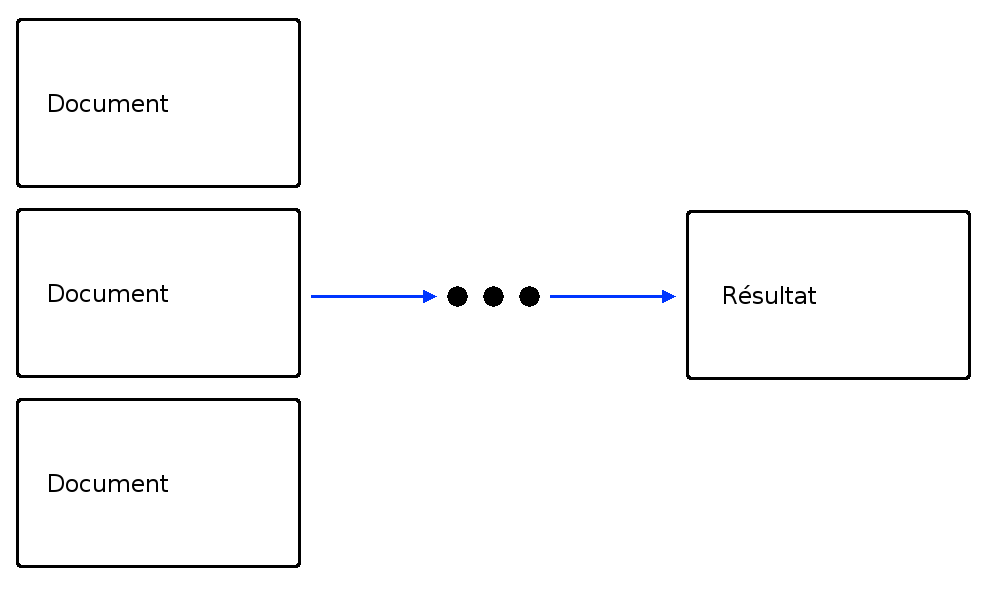

## Agrégateurs

Les méthodes `count` et `distinct` sont des agrégateurs.

[figure not shown]

```r
m$count('{"type_name": "Hero"}')
```

## Agrégateurs

Les méthodes `count` et `distinct` sont des agrégateurs.

[figure not shown]

```r
m$distinct(key="pack_name", query='{"type_name": "Hero"}')
```

## Pipeline d’agrégation

Le **pipeline d’agrégation** de MongoDB est une séquence de **stages** à traverser pour transformer des documents en un résultat agrégé.

Même si nous en verrons un autre dans la suite, il s’agit du modèle d’agrégation **privilégié** de MongoDB.

Les stages filtrent, transforment, groupent, trient, … les documents dans un ordre établi. Par exemple :

- `$match` (filtre comme avec `query`),
- `$group` (regroupe et accumule),
- `$sort` (trie).

Pour les autres stages (`$project`, `$limit`, `$skip`, `$sample`, `$out`,…), voir :  
https://docs.mongodb.com/manual/reference/operator/aggregation-pipeline/

## Pipeline d’agrégation - Méthode `aggregate`

La méthode `aggregate` permet de contruire un agrégateur basé sur le modèle du pipeline d’agrégation. Cette méthode prend un tableau en paramètre contenant les différentes étapes à réaliser.

## Pipeline d’agrégation - Méthode `aggregate`

La méthode `aggregate` permet de contruire un agrégateur basé sur le modèle du pipeline d’agrégation. Cette méthode prend un tableau en paramètre contenant les différentes étapes à réaliser.

Illustration avec `count` :

```r
m$aggregate('[
  { "$match": { "type_name": "Hero" } },
  { "$group": { "_id": null, "count": { "$sum": 1 } } }
]')
```

```
##   _id count
## 1  NA   253
```

## Pipeline d’agrégation - Méthode `aggregate`

```r
m$aggregate('[
  { "$match": { "type_name": "Hero" } },
  { "$group": { "_id": null, "count": { "$sum": 1 } } }
]')
```

Quelques explications :

- `$match` est similaire à `query`,
- le champ `_id` de `$group` reçoit la clé utilisée pour les groupes ou `null` pour considérer tous les documents,
- le champ `count` de `$group` est le nom de l’**accumulateur** défini en suivant,
- la valeur des accumulateurs est maintenue groupe par groupe,
- la définition des accumulateurs est évaluée pour chaque document.

## Pipeline d’agrégation - Exemple de `distinct`

Pour imiter la méthode `distinct`, nous pouvons utiliser

```r
m$aggregate('[
  { "$group": { "_id": "$sphere_name" } }
]')
```

```
##          _id
## 1    Tactics
## 2    Neutral
## 3       Lore
## 4     Spirit
## 5    Baggins
## 6 Fellowship
## 7 Leadership
```

## Pipeline d’agrégation - Exemple de `distinct`

Pour imiter la méthode `distinct`, nous pouvons utiliser

```r
m$aggregate('[
  { "$group": { "_id": "$sphere_name" } }
]')
```

ou bien

```r
m$aggregate('[
  { "$group": { "_id": null, "sphere_name": { "$addToSet": "$sphere_name" } } }
]')
```

```
##   _id                                                     sphere_name
## 1  NA Baggins, Spirit, Fellowship, Lore, Leadership, Neutral, Tactics
```

## Pipeline d’agrégation - Tri

Voici comment compter des effectifs et les trier :

```r
m$aggregate('[
  { "$group": { "_id": "$sphere_name", "count": { "$sum": 1 } } },
  { "$sort": { "count": -1 } }
]')
```

```
##          _id count
## 1 Leadership   286
## 2       Lore   280
## 3    Tactics   276
## 4     Spirit   269
## 5    Neutral   215
## 6 Fellowship    14
## 7    Baggins     4
```

## Pipeline d’agrégation - Table de contingence

Pour des effectifs croisés, `_id` est un peu plus compliqué …

```r
m$aggregate('[
  { "$group": { "_id": { "sphere_name": "$sphere_name", "type_name": "$type_name" },
                "count": { "$sum": 1 } } }
]') %>% head(10) # On retrouve les résultats du slide 72
```

```
##    _id.sphere_name     _id.type_name count
## 1          Tactics              Hero    59
## 2          Tactics        Attachment    63
## 3             Lore              Ally    89
## 4          Tactics Player Side Quest     2
## 5       Leadership             Event    75
## 6          Neutral          Campaign   105
## 7          Neutral          Contract    11
## 8           Spirit              Ally    86
## 9          Neutral              Ally    30
## 10          Spirit              Hero    60
```

## Pipeline d’agrégation - Opérateurs

Des opérateurs sont disponible pour calculer des résultats plus avancés.

```r
m$aggregate('[
  { "$group": { "_id": "$sphere_name",
                 "attack": { "$avg": "$attack" },
                 "defense": { "$avg": "$defense" } } }
]')
```

```
##          _id   attack  defense
## 1 Leadership 1.331081 1.135135
## 2    Tactics 2.000000 1.340580
## 3     Spirit 1.075342 1.095890
## 4       Lore 1.278146 1.066225
## 5    Neutral 2.477273 2.159091
## 6 Fellowship 1.750000 2.000000
## 7    Baggins 1.000000 1.000000
```

## Pipeline d’agrégation - Opérateurs

Des opérateurs sont disponible pour calculer des résultats plus avancés.

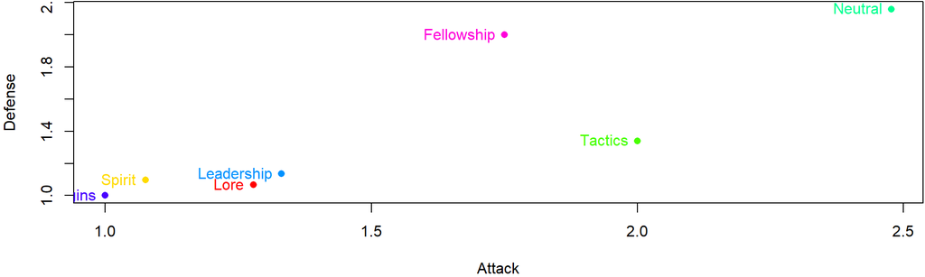

```r
m$aggregate('[
  { "$group": { "_id": "$sphere_name",
                 "attack": { "$avg": "$attack" },
                 "defense": { "$avg": "$defense" } } }
]')
```

## Pipeline d’agrégation - Opérateurs

Pour aller plus loin …  
https://docs.mongodb.com/manual/reference/operator/aggregation/

```r
m$aggregate('[
  { "$match": { "threat": { "$exists": true } } },
  { "$project": { "niveau": { "$cond": [ { "$lt": ["$threat", 10] },
                                        "Faiblard", "Balèze"] } } },
  { "$group": { "_id": "$niveau", "count": { "$sum": 1 } } }
]')
```

```
##        _id count
## 1 Faiblard   177
## 2   Balèze    76
```

## Pipeline d’agrégation - Limites

Chaque document de la collection résultante est limité à 16MB : il s’agit d’une contrainte liée au format BSON utilisé dans MongoDB.

Chaque stage est limité à 100MB de RAM : cela peut poser des problèmes lorsque les jeux de données sont volumineux.

Le pipeline est limité aux opérateurs définis par MongoDB : il n’est pas possible d’utiliser des fonctions plus “souples” pour calculer le résultat d’une agrégation.

## MapReduce

MongoDB propose une alternative pour réaliser des agrégations : **MapReduce**

MapReduce est un **patron d’architecture** breveté par Google en 2004. Le principe est de **paralléliser** les calculs qui peuvent alors être **distribués** et de rendre cela invisible à l’utilisateur. Pour cela, MapReduce opère en deux étapes :

- **map** : fonction appliquée à chaque document qui **émet** une sortie,
- **reduce** : les sorties des appels **map** sont regroupées pour produire le résultat.

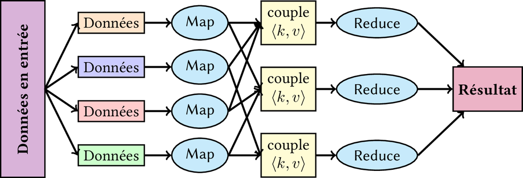

## MapReduce

Quelques remarques pour MapReduce avec MongoDB :

- la sortie d’un **map** est un document, *i.e.* des paires clé/valeur,
- les fonctions **map** et **reduce** sont écrites en JavaScript (pas en **R**),
- le nom de la méthode à utiliser est `mapreduce`,
- il est possible de limiter MapReduce au résultat d’une recherche avec le paramètre `query` ou de trier le résultat avec `sort`.

MapReduce offre plus de souplesse que le pipeline d’agrégation mais ce dernier doit rester le choix à privilégier car MapReduce est moins efficace et plus complexe en général.

## MapReduce - Compter des effectifs

Considérons un premier exemple simple de MapReduce :

```
##                      _id value
## 1 A Journey to Rhosgobel    10
## 2   A Shadow in the East    13
## 3 A Storm on Cobas Haven    11
## 4  Across the Ettenmoors    10
## 5   Assault on Osgiliath    10
## 6      Beneath the Sands    10
## 7   Celebrimbor's Secret    10
```

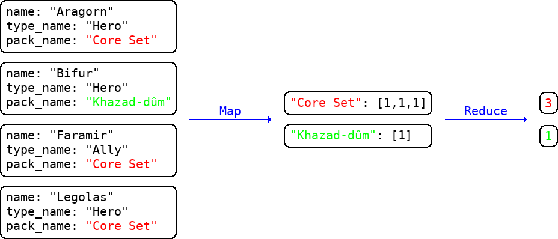

```r
m$mapreduce('function() { emit(this.pack_name, 1) }',
            'function(key, values) { return Array.sum(values) }') %>% head(7)
```

## MapReduce - Calculer des moyennes

Voici comment obtenir la longueur moyenne des noms en fonction de la *Sphere* :

```r
m$mapreduce('function() { emit(this.sphere_name, this.name.length) }',
            'function(key, values) { return Array.sum(values) / values.length }')
```

```
##          _id    value
## 1    Baggins 14.25000
## 2 Fellowship 12.79592
## 3 Leadership 17.74189
## 4       Lore 16.76224
## 5    Neutral 15.01199
## 6     Spirit 15.39616
## 7    Tactics 12.87548
```

À vous de jouer!